# Assignment #1 - Data set selection and initial Processing

Xinyi Zhang

23 February 2022

```r
#Loading packages
if (!requireNamespace("BiocManager", quietly = TRUE))
install.packages("BiocManager");library(BiocManager)
if (!requireNamespace("GEOmetadb", quietly = TRUE))
BiocManager::install("GEOmetadb");library(GEOmetadb)
#Loading packages
if (!require("pacman")) install.packages("pacman")
pacman::p_load(tidyverse,gridExtra,knitr,
               kableExtra,sjPlot,reshape2,readr)
## setting options
knitr::opts_chunk$set(message = F,warning = F)
```

## Getting Data and connecting data to Geo Data

```r
## Geeting meta data
if(!file.exists('GEOmetadb.sqlite')) getSQLiteFile()
## Connecting data
conect_data <- dbConnect(SQLite(),'GEOmetadb.sqlite')
```

```r
## Getting RNA-Seq Data
sql <- paste("SELECT DISTINCT gse.title,gse.gse, gpl.title,",
             " gse.submission_date",
             "FROM",
             " gse JOIN gse_gpl ON gse_gpl.gse=gse.gse",
             " JOIN gpl ON gse_gpl.gpl=gpl.gpl",
             "WHERE",
             " gse.submission_date > '2015-01-01' AND",
             " gse.title LIKE '%SARS-CoV-2%' AND ",
             " gpl.organism LIKE '%Homo sapiens%' AND",
             " gpl.technology LIKE '%high-throughput seq%' ",sep=" ")
## Data file
rna_seq <- dbGetQuery(conect_data,sql);rna_seq
```

| title | gse | title | submission_date |
| --- | --- | --- | --- |
| Transcriptional response of human lung epithelial cells to SARS-CoV-2 infection | GSE147507 | Illumina NextSeq 500 (Homo sapiens) | 2020-03-24 |
| SARS-CoV-2 receptor ACE2 is an interferon-stimulated gene in human airway epithelial cells and is detected in specific cell subsets across tissues | GSE148829 | Illumina NextSeq 500 (Homo sapiens) | 2020-04-17 |
| SARS-CoV-2 receptor ACE2 is an interferon-stimulated gene in human airway epithelial cells and is detected in specific cell subsets across tissues | GSE148829 | Illumina NovaSeq 6000 (Homo sapiens) | 2020-04-17 |
| Bulk RNA sequencing of SARS-CoV and SARS-CoV-2 infected human intestinal organoids | GSE149312 | Illumina NextSeq 500 (Homo sapiens) | 2020-04-24 |
| Spectrum of Viral Load and Host Response Seen in Autopsies of SARS-CoV-2 Infected Lungs | GSE150316 | Illumina NextSeq 500 (Homo sapiens) | 2020-05-11 |
| Generation of human bronchial organoids for SARS-CoV-2 research | GSE150819 | Illumina NextSeq 500 (Homo sapiens) | 2020-05-19 |
| Generation of human bronchial organoids for SARS-CoV-2 research | GSE150819 | Illumina NovaSeq 6000 (Homo sapiens) | 2020-05-19 |
| A Platform to Define Cellular Targets of SARS-COV-2 Infection Using Human Pluripotent Stem Cell-Derived Cells and Organoids | GSE147903 | Illumina NextSeq 500 (Homo sapiens) | 2020-04-01 |
| RNA-Seq of Human iPSC-cardiomyocytes infected with SARS-CoV-2 | GSE150392 | Illumina NextSeq 500 (Homo sapiens) | 2020-05-12 |
| In vivo antiviral host response to SARS-CoV-2 by viral load, sex, and age | GSE152075 | Illumina NextSeq 500 (Homo sapiens) | 2020-06-09 |

[output cut: 84 more lines]

The data is extracted from the tile `Alveolitis in severe SARS-CoV-2 pneumonia is driven by self-sustaining circuits between infected alveolar macrophages and T cells`, with GSE code of `GSE155249`. The dataset is associated with following article. [https://pubmed.ncbi.nlm.nih.gov/34013276/]

## Description of data

They compared BAL samples from 86 patients with respiratory failure caused by severe SARS-CoV-2 pneumonia to BAL specimens from 252 patients with pneumonia caused by other infections and intubated patients without pneumonia, which were collected prospectively before and throughout the pandemic. They got samples from numerous patients within 48 hours of intubation and sequentially throughout their illness, which allowed us to learn more about the early aetiology of COVID-19-induced acute respiratory distress syndrome (ARDS). Multicolor flow cytometry was used to identify CD4+ and CD8+ T cells, monocytes, mature and immature alveolar macrophages, and neutrophils in BAL samples. In a subset of patients with confirmed COVID-19, we also did bulk transcriptome profiling of flow cytometry-sorted alveolar macrophages. In addition, they used single cell RNA-Seq on BAL fluid from 5 patients with severe SARS-CoV-2 pneumonia who were intubated less than 48 hours after infection.

## Geo description of dataset

The Geo description of this data set is given below.

```r
gse <- getGEO("GSE155249",GSEMatrix=FALSE)
tab_df(data.frame(head(Meta(gse))), title = "Geo description of dataset")
```

Geo description of dataset

| contact_address | contact_city | contact_country | contact_email | contact_institute | contact_name |
| --- | --- | --- | --- | --- | --- |
| 303 E Superior | Chicago | USA | a-misharin@northwestern.edu | Northwestern University | Alexander,V,Misharin |

## Information about platform

```r
current_gpl <- names(GPLList(gse))[1]
current_gpl_info <- Meta(getGEO(current_gpl))
## Title
current_gpl_info$title
```

```
## [1] "Illumina NovaSeq 6000 (Homo sapiens)"
```

```r
## Submission date
current_gpl_info$submission_date
```

```
## [1] "Mar 02 2018"
```

```r
## Last update
current_gpl_info$last_update_date
```

```
## [1] "Nov 05 2018"
```

```r
## orgnism
current_gpl_info$organism
```

```
## [1] "Homo sapiens"
```

```r
Platform <- tibble(`Information`=c("Platform title",
                        "Submission data",
                        "Last update data",
                        "Organims",
                        "Number of GEO datasets that use this techology",
                        "Number of GEO samples that use this technology"),
                       `Description` = c(current_gpl_info$title,
                              current_gpl_info$submission_date,
                              current_gpl_info$last_update_date,
                              current_gpl_info$organism,
                              length(current_gpl_info$series_id),
                              length(current_gpl_info$sample_id)));
# Print table
tab_df(Platform, title = "Table: Information about platform")
```

Table: Information about platform

| Information | Description |
| --- | --- |
| Platform title | Illumina NovaSeq 6000 (Homo sapiens) |
| Submission data | Mar 02 2018 |
| Last update data | Nov 05 2018 |
| Organims | Homo sapiens |
| Number of GEO datasets that use this techology | 4132 |
| Number of GEO samples that use this technology | 95097 |

## Getting Selected Expression data

Here is the function that will download the data, and only download when there its not exist, other wise only load it from the file.

```r
## Function
get_raw <- function (gse_names, data_dir = getwd()) {

    for (gse_name in gse_names) {

        gse_dir <- file.path(data_dir, gse_name)
        work_dir  <- getwd()

        # get raw data
        if (!file.exists(gse_dir)) {
            crossmeta:::getGEOSuppFiles(gse_name, baseDir = data_dir)
        }

        # untar
        tar_names <- list.files(gse_dir, pattern = "\\.tar$", full.names = TRUE)
        if (length(tar_names) > 0) {
            res <- 1; try <- 0
            while (res != 0 & try != 3) {
                res <- try(utils::untar(tar_names,  exdir=gse_dir))
                if (res != 0) Sys.sleep(10); try <- try + 1
            }
        }
        # unzip
        paths <- list.files(gse_dir, pattern = "\\.gz$",
                            full.names = TRUE, ignore.case = TRUE)
        sapply(paths, GEOquery::gunzip, overwrite = TRUE)
    }
}
```

```r
# get raw data
get_raw('GSE155249')
# there is only one supplemental file
supplement_data = read_csv("GSE155249/GSE155249_supplement-metadata.csv")
tab_df(head(supplement_data),title="Table: Overview of the expression data")
```

Table: Overview of the expression data

| …1 | Patient | Day.after.intubation | Sample.type | Sample | Sample.status | Cluster | COVID.19 | No.of.SARS.CoV.2.genes | IFNA.Response | IFNG.Response | No.of.genes | No.of.UMIs | X..of.mito.genes | X..of.ribo.genes |
| --- | --- | --- | --- | --- | --- | --- | --- | --- | --- | --- | --- | --- | --- | --- |
| AAACCTGAGAAACCGC-0 | 4 | 1 | BAL | 1 | Fresh | iNKT cells | TRUE | 1 | 0.16 | 0.20 | 636 | 961 | 2.71 | 24.04 |
| AAACCTGAGCGTTTAC-0 | 4 | 1 | BAL | 1 | Fresh | CD8 cytotoxic T cells | TRUE | 0 | 0.41 | 0.32 | 577 | 754 | 1.19 | 12.86 |
| AAACCTGCAACTGCGC-0 | 4 | 1 | BAL | 1 | Fresh | MoAM2 | TRUE | 11 | 0.65 | 0.59 | 1026 | 1922 | 2.19 | 8.69 |
| AAACCTGCATTGAGCT-0 | 4 | 1 | BAL | 1 | Fresh | CD4 CM T cells | TRUE | 0 | 0.95 | 0.55 | 690 | 1132 | 0.71 | 25.71 |
| AAACCTGTCGGATGTT-0 | 4 | 1 | BAL | 1 | Fresh | TRAM1 | TRUE | 1 | 0.20 | 0.21 | 1316 | 3783 | 3.44 | 16.02 |
| AAACGGGAGCTAAGAT-0 | 4 | 1 | BAL | 1 | Fresh | CD8 cytotoxic T cells | TRUE | 0 | 0.17 | 0.22 | 597 | 802 | 0.87 | 18.08 |

## Cleaning the data

FOr cleaning data, we will mainly explore the following points.

1. How many unique genes do we have?
2. Are there any non-genes in our dataset? If so what are they?
3. Can we exclude them?

## Checking the number of genes in data file

```r
dim(supplement_data)
```

```
## [1] 105715     15
```

It can be observed that there are 105715 genes, and 15 columns.

## CHecking the names of all columns in data

How can we retrieve the information that belongs to each sample given the absence of definition in format?

```r
## Checking column names
colnames(supplement_data)
```

```
##  [1] "...1"                   "Patient"                "Day after intubation"
##  [4] "Sample type"            "Sample"                 "Sample status"
##  [7] "Cluster"                "COVID-19"               "No of SARS-CoV-2 genes"
## [10] "IFNA Response"          "IFNG Response"          "No of genes"
## [13] "No of UMIs"             "% of mito genes"        "% of ribo genes"
```

```r
## Renaming the ID
names(supplement_data)[1] <- "Genes_ID"
```

## Checking the duplicated genes

```r
summarized_gene_counts <- sort(table(supplement_data$Genes_ID),
                               decreasing = TRUE)

kable(summarized_gene_counts[which(summarized_gene_counts>1)[1:10]],format = "html")
```

| Var1 | Freq |
| --- | --- |
| NA | NA |
| NA | NA |
| NA | NA |
| NA | NA |
| NA | NA |
| NA | NA |
| NA | NA |
| NA | NA |
| NA | NA |
| NA | NA |

It shows that there is no duplicate genes ID in the data, and there is no need to remove any of the row from data.

## Checking missing values in data

```r
sum(is.na(supplement_data))
```

```
## [1] 0
```

There is no missing value in the data.

## Checking outliers in numeric variable

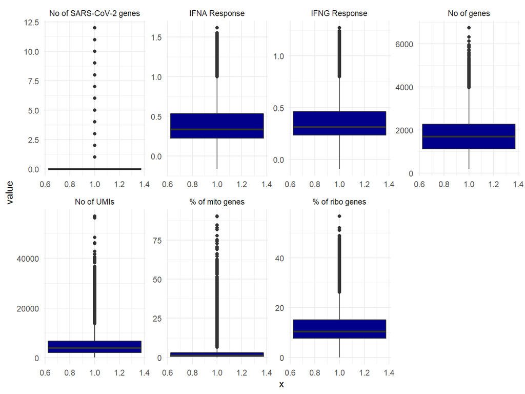

```r
melt(supplement_data[,9:15]) %>%
  ggplot(aes(x=1,y=value))+
  geom_boxplot(fill="dark blue")+
  theme_minimal() +
  theme(legend.position = "none")+
  facet_wrap(variable~.,scales="free",ncol=4)
```

The boxplot shows that there are many extreme outliers in the variable `No of SARS-CoV-2 genes`.

## Removing outliers

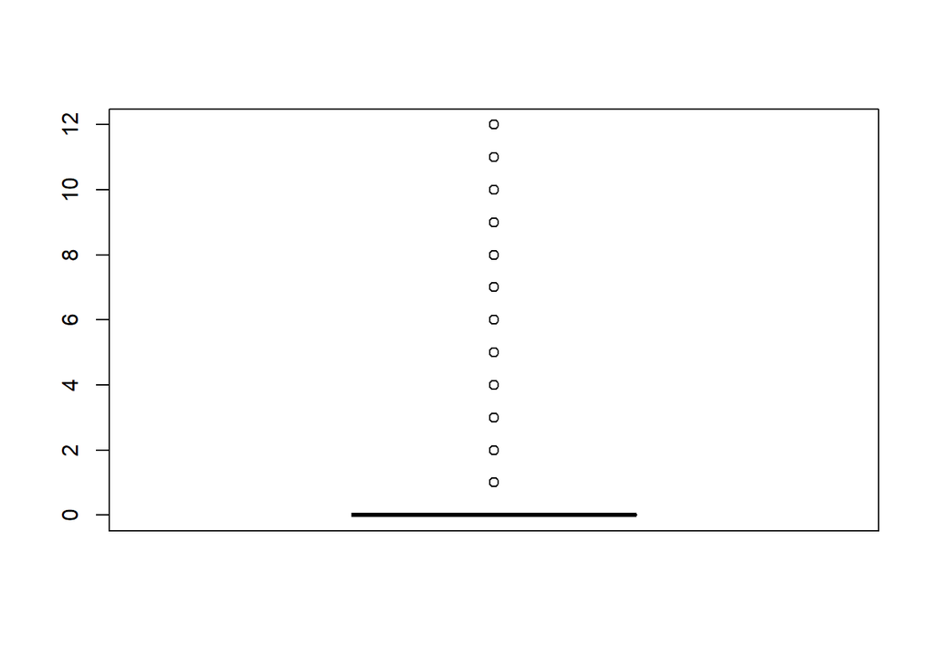

```r
## Outliers
OutVals <- boxplot(supplement_data$`No of SARS-CoV-2 genes`)$out
```

```r
## removing outliers
supplement_data$`No of SARS-CoV-2 genes` <- ifelse(
  supplement_data$`No of SARS-CoV-2 genes` == OutVals, NA,
  supplement_data$`No of SARS-CoV-2 genes`
)
## Outliers
sum(is.na(supplement_data$`No of SARS-CoV-2 genes`))
```

```
## [1] 2774
```

```r
## Removing outliers
supplement_data <- na.omit(supplement_data)
```

## Normalization of data

Firstly, we will check the data normality by plotting the histogram.

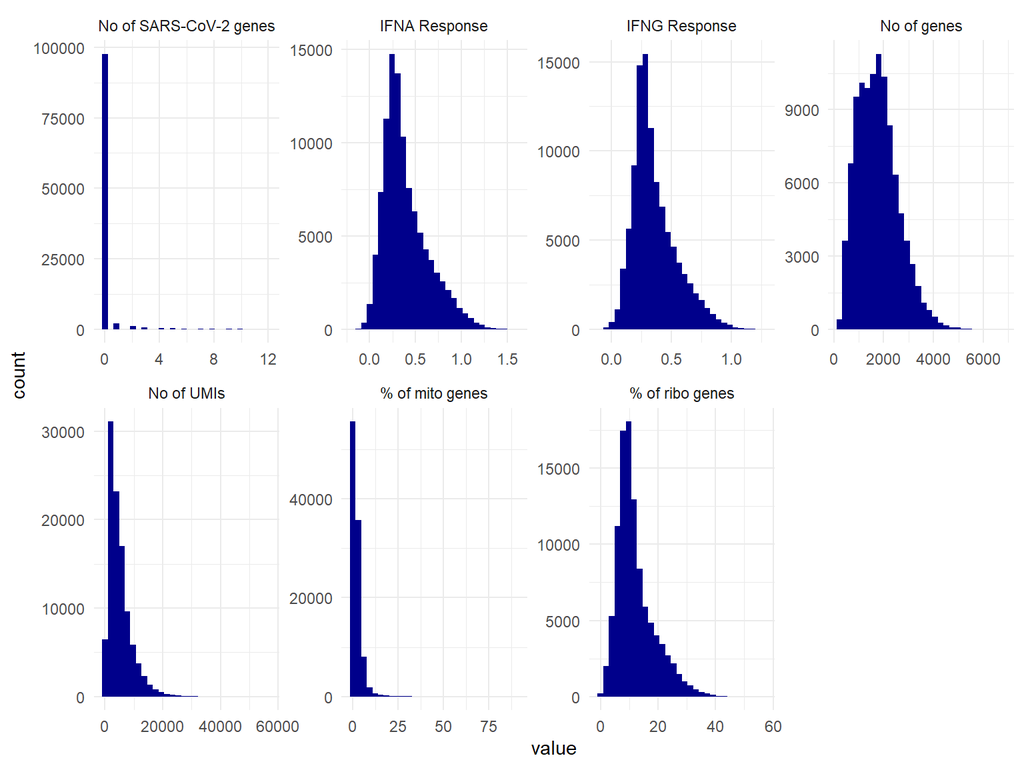

```r
melt(supplement_data[,9:15]) %>%
  ggplot(aes(x=value))+
  geom_histogram(fill="dark blue")+
  theme_minimal() +
  theme(legend.position = "none")+
  facet_wrap(variable~.,scales="free",ncol=4)
```

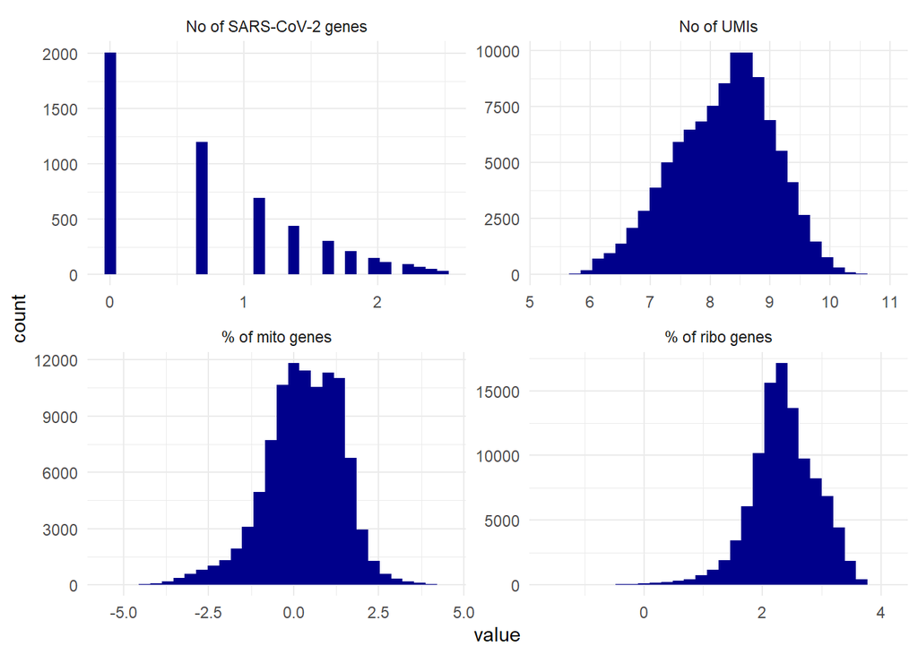

```r
## Taking log of variables
supplement_data$`No of SARS-CoV-2 genes` <- log(supplement_data$`No of SARS-CoV-2 genes`)
supplement_data$`No of UMIs` <- log(supplement_data$`No of UMIs`)
supplement_data$`% of mito genes` <- log(supplement_data$`% of mito genes`)
supplement_data$`% of ribo genes` <- log(supplement_data$`% of ribo genes`)
## Plotting the histogram
melt(supplement_data[,c(9,13:15)]) %>%
  ggplot(aes(x=value))+
  geom_histogram(fill="dark blue")+
  theme_minimal() +
  theme(legend.position = "none")+
  facet_wrap(variable~.,scales="free",ncol=2)
```

## Final coverage of data

```r
## Structure of data
str(supplement_data)
```

```
## tibble [102,941 x 15] (S3: tbl_df/tbl/data.frame)
##  $ Genes_ID              : chr [1:102941] "AAACCTGAGCGTTTAC-0" "AAACCTGCAACTGCGC-0" "AAACCTGCATTGAGCT-0" "AAACCTGTCGGATGTT-0" ...
##  $ Patient               : chr [1:102941] "4" "4" "4" "4" ...
##  $ Day after intubation  : num [1:102941] 1 1 1 1 1 1 1 1 1 1 ...
##  $ Sample type           : chr [1:102941] "BAL" "BAL" "BAL" "BAL" ...
##  $ Sample                : num [1:102941] 1 1 1 1 1 1 1 1 1 1 ...
##  $ Sample status         : chr [1:102941] "Fresh" "Fresh" "Fresh" "Fresh" ...
##  $ Cluster               : chr [1:102941] "CD8 cytotoxic T cells" "MoAM2" "CD4 CM T cells" "TRAM1" ...
##  $ COVID-19              : logi [1:102941] TRUE TRUE TRUE TRUE TRUE TRUE ...
##  $ No of SARS-CoV-2 genes: num [1:102941] -Inf 2.4 -Inf 0 -Inf ...
##  $ IFNA Response         : num [1:102941] 0.414 0.653 0.954 0.204 0.17 ...
##  $ IFNG Response         : num [1:102941] 0.316 0.588 0.553 0.207 0.217 ...
##  $ No of genes           : num [1:102941] 577 1026 690 1316 597 ...
##  $ No of UMIs            : num [1:102941] 6.63 7.56 7.03 8.24 6.69 ...
##  $ % of mito genes       : num [1:102941] 0.177 0.782 -0.347 1.234 -0.136 ...
##  $ % of ribo genes       : num [1:102941] 2.55 2.16 3.25 2.77 2.89 ...
##  - attr(*, "na.action")= 'omit' Named int [1:2774] 1 11 37 46 50 56 57 68 78 87 ...
##   ..- attr(*, "names")= chr [1:2774] "1" "11" "37" "46" ...
```